# Introducción a ggplot2

José Roberto Bermúdez Barrientos

12/17/2020

### Sitio en construcción!

#### Instalar y cargar

Lo primero que hay que hacer es instalar la librería ggplot2:

```r
install.packages("ggplot2")
```

Una vez instalado un paquete en R, debería estar disponible para su uso mediante la función library(). No es necesario instalar un paquete cada vez que se inicie una sesión de R.

Posteriormente hay que cargar la librería de ggplot2.

```r
library(ggplot2)
```

Para empezar a usar ggplot2 vamos a trabajar con el objeto iris, el cual se encuentra pre-cargado dentro de cualquier sesión de R.

#### El primer vistazo a los datos

El primer paso para explorar un objeto con datos es echarle un vistazo y familiarizarse con su contenido. Para ello recomiendo usar la función head(), ya que puede haber objetos bastante grandes e imprimirlos por completo puede resultar contraproducente.

```r
head(iris)
```

```
##   Sepal.Length Sepal.Width Petal.Length Petal.Width Species
## 1          5.1         3.5          1.4         0.2  setosa
## 2          4.9         3.0          1.4         0.2  setosa
## 3          4.7         3.2          1.3         0.2  setosa
## 4          4.6         3.1          1.5         0.2  setosa
## 5          5.0         3.6          1.4         0.2  setosa
## 6          5.4         3.9          1.7         0.4  setosa
```

Otras funciones útiles para familiarizarse con los datos son str() y summary().

```r
str(iris)
```

```
## 'data.frame':    150 obs. of  5 variables:
##  $ Sepal.Length: num  5.1 4.9 4.7 4.6 5 5.4 4.6 5 4.4 4.9 ...
##  $ Sepal.Width : num  3.5 3 3.2 3.1 3.6 3.9 3.4 3.4 2.9 3.1 ...
##  $ Petal.Length: num  1.4 1.4 1.3 1.5 1.4 1.7 1.4 1.5 1.4 1.5 ...
##  $ Petal.Width : num  0.2 0.2 0.2 0.2 0.2 0.4 0.3 0.2 0.2 0.1 ...
##  $ Species     : Factor w/ 3 levels "setosa","versicolor",..: 1 1 1 1 1 1 1 1 1 1 ...
```

```r
summary(iris)
```

```
##   Sepal.Length    Sepal.Width     Petal.Length    Petal.Width
##  Min.   :4.300   Min.   :2.000   Min.   :1.000   Min.   :0.100
##  1st Qu.:5.100   1st Qu.:2.800   1st Qu.:1.600   1st Qu.:0.300
##  Median :5.800   Median :3.000   Median :4.350   Median :1.300
##  Mean   :5.843   Mean   :3.057   Mean   :3.758   Mean   :1.199
##  3rd Qu.:6.400   3rd Qu.:3.300   3rd Qu.:5.100   3rd Qu.:1.800
##  Max.   :7.900   Max.   :4.400   Max.   :6.900   Max.   :2.500
##        Species
##  setosa    :50
##  versicolor:50
##  virginica :50
##
##
##
```

#### El alimento favorito de ggplot2

La entrada favorita para las funciones de ggplot2 son los data.frames para los cuales cada fila corresponde a una observación y cada columna corresponde a una variable. Una opción popular para generar dichos tipos de data.frames son tidyr. https://tidyr.tidyverse.org/

ggplot2 también usa el concepto de factor, el cual es un tipo de dato usado para representar variables categóricas. Un ejemplo de variables categoricas es la especie de flor en el data.frame iris, o el sexo de perros hembra o macho.

En la siguiente línea llamamos a la función ggplot para empezar a estructurar nuestra figura.

```r
grafica <- ggplot(data = iris, aes(x = Sepal.Length, y=Sepal.Width))
grafica <- grafica + geom_point(aes(color=Species))
```

Se ve un poco intimidante no? vamos a ver que hace cada uno de los pedazos de código, pero por lo pronto vamos a visualizar los datos.

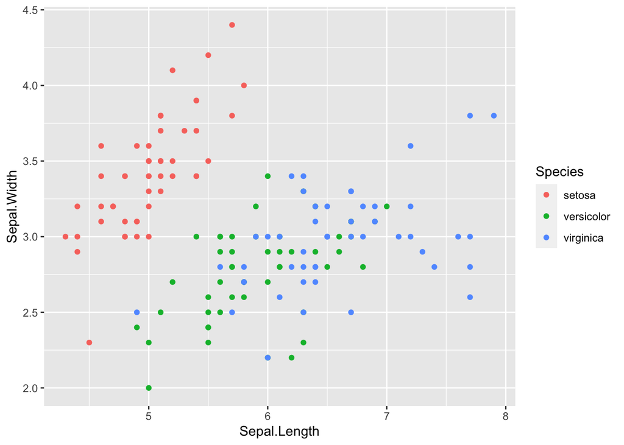

```r
grafica
```

Ahora sí, vamos a desmenuzar qué hace cada uno de los componentes del código.

data = indica el objeto donde tenemos almacenados los datos, en este caso **iris**. aes() representa los parámetros estéticos (por sus siglas en inglés aesthetic), en éste caso indicamos que vamos a usar información de la columna Sepal.Length para el eje de las x y usaremos la columna Sepal.Width para el eje de las y.

Todo el resultado de la función ggplot() lo almacenamos en un objeto, que en este caso se llama grafica. Podemos elegir el nombre de nuestra preferencia para dicho objeto. Frecuentemente verás en foros que se suelen usar nombres muy cortos para las variables que almacenan las gráficas como p, s, etc. En éste caso opte por un nombre en español para resaltar el contraste entre variables internas y variables de nuestra creación.

Esta es otra de las peculariedades de ggplot2, almacenamos gráficos en objectos y posteriormente podemos añadir mayor complejidad a dichos objectos.

Finalmente llamamos geom_point() para indicar que queremos usar puntos para representar los datos a graficar. Dentro de geom_point() también podemos usar aes() para definir parametros estéticos en éste caso color=Species indica que queremos colorear de acuerdo a la columna Species que contiene un factor.

Algo que llama la atención de cómo llamamos a la función geom_point() es que la sumamos a nuestro objeto grafica:

grafica + geom_point()

Esto es debido al sistema de capas de ggplot2, lo cual discutiremos más a fondo abajo.

#### ggplot2 y su sistema de capas

ggplot2 funciona con un sistema de capas, ya tuviste una primera experiencia esto. En la figura anterior tenemos grafica + geom_point().

Qué pasa si definimos la gráfica con ggplot(), pero no añadimos la capa de geom_point()?

```r
grafica <- ggplot(data = iris, aes(x = Sepal.Length, y=Sepal.Width))
```

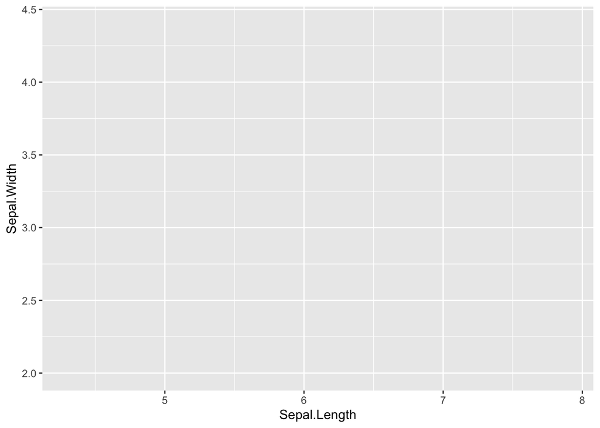

```r
grafica
```

Como podemos ver, llamar solamente a ggplot resulta en una gráfica “vacía”.